# item Recommender

Exploratory Analysis

Have you ever wondered which book to read next? I often have and to me, book recommendations are a fascinating issue. This external dataset allows us to take a deeper look at data-driven item recommendations.

- **Part I:** explores the dataset to find some interesting insights.  
  As an appetizer here you can access (just click on the image) the finished fully functional book recommender based on ratings of this dataset:

[figure not shown]

Let’s go.

user self selection bias https://arxiv.org/pdf/1602.05352v1.pdf

Most popular of genera include raters not fans of genera.

better names for a bunch of my code. possibly explanations. recompute mean and median and sd and outliers for ‘books’ after user item selection, twihlight sd is very large?

check every single kaggel notebook on these things, highly rated python too.

```r
library(recommenderlab)
library(data.table)
library(dplyr)
library(tidyr)
library(ggplot2)
library(stringr)
library(DT)
library(knitr)
library(grid)
library(gridExtra)
library(corrplot)
library(qgraph)
library(methods)
library(Matrix)

input.folder<-"badbooks"
output.name<-paste(input.folder,"4",sep = "") ###only after selection
books <- fread(paste(input.folder,'/item_content.csv',sep = ""))
ratings <- fread(paste(input.folder,'/ratings.csv',sep = ""))
item_tags <- fread(paste(input.folder,'/item_tags.csv',sep = ""))
tags <- fread(paste(input.folder,'/tags.csv',sep = ""))
```

#### Have a look at the dataset

First, let’s have a look at the dataset. It consists of the files: `ratings.csv`, `books.csv`, `item_tags.csv`, `tags.csv`.

These two files are linked by the items’ ids.

#### Ratings.csv

|  | user_id | item_id | rating |
| --- | --- | --- | --- |
| 1 | 1 | 258 | 5 |
| 2 | 2 | 4081 | 4 |
| 3 | 2 | 260 | 5 |
| 4 | 2 | 9296 | 5 |
| 5 | 2 | 2318 | 3 |
| 6 | 2 | 26 | 4 |
| 7 | 2 | 315 | 3 |
| 8 | 2 | 33 | 4 |
| 9 | 2 | 301 | 5 |
| 10 | 2 | 2686 | 5 |

```
## Observations: 5,976,479
## Variables: 3
## $ user_id <int> 1, 2, 2, 2, 2, 2, 2, 2, 2, 2, 2, 2, 4, 4, 4, 4, 4, 4, ...
## $ item_id <int> 258, 4081, 260, 9296, 2318, 26, 315, 33, 301, 2686, 37...
## $ rating  <int> 5, 4, 5, 5, 3, 4, 3, 4, 5, 5, 5, 5, 4, 3, 4, 5, 5, 5, ...
```

#### Books.csv

|  | book_id | goodreads_book_id | popular_edition | work_id | editions_count | isbn | isbn13 | authors | original_publication_year | original_title | title | language_code | average_rating | ratings_count | work_ratings_count | work_text_reviews_count | ratings_1 | ratings_2 | ratings_3 | ratings_4 | ratings_5 | image_url | small_image_url |
| --- | --- | --- | --- | --- | --- | --- | --- | --- | --- | --- | --- | --- | --- | --- | --- | --- | --- | --- | --- | --- | --- | --- | --- |
| 1 | 1 | 2767052 | 2767052 | 2792775 | 272 | 439023483 | 9780439023480 | Suzanne Collins | 2008 | The Hunger Games | The Hunger Games (The Hunger Games, #1) | eng | 4.34 | 4780653 | 4942365 | 155254 | 66715 | 127936 | 560092 | 1481305 | 2706317 | https://images.gr-assets.com/books/1447303603m/2767052.jpg | https://images.gr-assets.com/books/1447303603s/2767052.jpg |
| 2 | 2 | 3 | 3 | 4640799 | 491 | 439554934 | 9780439554930 | J.K. Rowling, Mary GrandPrÃ© | 1997 | Harry Potter and the Philosopher's Stone | Harry Potter and the Sorcerer's Stone (Harry Potter, #1) | eng | 4.44 | 4602479 | 4800065 | 75867 | 75504 | 101676 | 455024 | 1156318 | 3011543 | https://images.gr-assets.com/books/1474154022m/3.jpg | https://images.gr-assets.com/books/1474154022s/3.jpg |
| 3 | 3 | 41865 | 41865 | 3212258 | 226 | 316015849 | 9780316015840 | Stephenie Meyer | 2005 | Twilight | Twilight (Twilight, #1) | en-US | 3.57 | 3866839 | 3916824 | 95009 | 456191 | 436802 | 793319 | 875073 | 1355439 | https://images.gr-assets.com/books/1361039443m/41865.jpg | https://images.gr-assets.com/books/1361039443s/41865.jpg |
| 4 | 4 | 2657 | 2657 | 3275794 | 487 | 61120081 | 9780061120080 | Harper Lee | 1960 | To Kill a Mockingbird | To Kill a Mockingbird | eng | 4.25 | 3198671 | 3340896 | 72586 | 60427 | 117415 | 446835 | 1001952 | 1714267 | https://images.gr-assets.com/books/1361975680m/2657.jpg | https://images.gr-assets.com/books/1361975680s/2657.jpg |
| 5 | 5 | 4671 | 4671 | 245494 | 1356 | 743273567 | 9780743273560 | F. Scott Fitzgerald | 1925 | The Great Gatsby | The Great Gatsby | eng | 3.89 | 2683664 | 2773745 | 51992 | 86236 | 197621 | 606158 | 936012 | 947718 | https://images.gr-assets.com/books/1490528560m/4671.jpg | https://images.gr-assets.com/books/1490528560s/4671.jpg |

```
## Observations: 10,000
## Variables: 23
## $ book_id                   <int> 1, 2, 3, 4, 5, 6, 7, 8, 9, 10, 11, 1...
## $ goodreads_book_id         <int> 2767052, 3, 41865, 2657, 4671, 11870...
## $ popular_edition           <int> 2767052, 3, 41865, 2657, 4671, 11870...
## $ work_id                   <int> 2792775, 4640799, 3212258, 3275794, ...
## $ editions_count            <int> 272, 491, 226, 487, 1356, 226, 969, ...
## $ isbn                      <chr> "439023483", "439554934", "316015849...
## $ isbn13                    <dbl> 9.780439e+12, 9.780440e+12, 9.780316...
## $ authors                   <chr> "Suzanne Collins", "J.K. Rowling, Ma...
## $ original_publication_year <dbl> 2008, 1997, 2005, 1960, 1925, 2012, ...
## $ original_title            <chr> "The Hunger Games", "Harry Potter an...
## $ title                     <chr> "The Hunger Games (The Hunger Games,...
## $ language_code             <chr> "eng", "eng", "en-US", "eng", "eng",...
## $ average_rating            <dbl> 4.34, 4.44, 3.57, 4.25, 3.89, 4.26, ...
## $ ratings_count             <int> 4780653, 4602479, 3866839, 3198671, ...
## $ work_ratings_count        <int> 4942365, 4800065, 3916824, 3340896, ...
## $ work_text_reviews_count   <int> 155254, 75867, 95009, 72586, 51992, ...
## $ ratings_1                 <int> 66715, 75504, 456191, 60427, 86236, ...
## $ ratings_2                 <int> 127936, 101676, 436802, 117415, 1976...
## $ ratings_3                 <int> 560092, 455024, 793319, 446835, 6061...
## $ ratings_4                 <int> 1481305, 1156318, 875073, 1001952, 9...
## $ ratings_5                 <int> 2706317, 3011543, 1355439, 1714267, ...
## $ image_url                 <chr> "https://images.gr-assets.com/books/...
## $ small_image_url           <chr> "https://images.gr-assets.com/books/...
```

```
##  [1] "eng"   "en-US" "en-CA" ""      "spa"   "en-GB" "fre"   "nl"
##  [9] "ara"   "por"   "ger"   "nor"   "jpn"   "en"    "vie"   "ind"
## [17] "pol"   "tur"   "dan"   "fil"   "ita"   "per"   "swe"   "rum"
## [25] "mul"   "rus"
```

#### item_tags.csv

|  | goodreads_book_id | tag_id | count |
| --- | --- | --- | --- |
| 1 | 1 | 30574 | 167697 |
| 2 | 1 | 11305 | 37174 |
| 3 | 1 | 11557 | 34173 |
| 4 | 1 | 8717 | 12986 |
| 5 | 1 | 33114 | 12716 |
| 6 | 1 | 11743 | 9954 |
| 7 | 1 | 14017 | 7169 |
| 8 | 1 | 5207 | 6221 |
| 9 | 1 | 22743 | 4974 |
| 10 | 1 | 32989 | 4364 |

```
## Observations: 999,912
## Variables: 3
## $ goodreads_book_id <int> 1, 1, 1, 1, 1, 1, 1, 1, 1, 1, 1, 1, 1, 1, 1,...
## $ tag_id            <int> 30574, 11305, 11557, 8717, 33114, 11743, 140...
## $ count             <int> 167697, 37174, 34173, 12986, 12716, 9954, 71...
```

#### Tags.csv

|  | tag_id | tag_name |
| --- | --- | --- |
| 14649 | 14648 | hitchhiker |
| 14270 | 14269 | henry-s-book-shelf |
| 22662 | 22661 | own-but-haven-t-read-yet |
| 23948 | 23947 | politique |
| 9841 | 9840 | dr-phil |
| 5671 | 5670 | breaking-the-rules |
| 15159 | 15158 | i-love-animals |
| 22443 | 22442 | operations-management |
| 313 | 312 | 13-16 |
| 2595 | 2594 | anime-bleach |

```
## Observations: 34,252
## Variables: 2
## $ tag_id   <int> 0, 1, 2, 3, 4, 5, 6, 7, 8, 9, 10, 11, 12, 13, 14, 15,...
## $ tag_name <chr> "-", "--1-", "--10-", "--12-", "--122-", "--166-", "-...
```

#### Top 100 rated items

Books only: It is apparent that users seem to like a) Calvin and Hobbes in general, b) compilations of items. This makes sense intuitively as people won’t get interested in an entire compilation if they don’t like the individual items. The other two data frame outputs are the most and least popular of top 100 rated.

```r
books %>%
  mutate(image = paste0('<img src="', small_image_url, '"></img>')) %>%
  arrange(-average_rating) %>%
  top_n(100,wt = average_rating) %>%
  select( title, work_ratings_count, average_rating)
```

```
##                                                                                                                                              title
## 1                                                                                                                   The Complete Calvin and Hobbes
## 2                                                                                                   Words of Radiance (The Stormlight Archive, #2)
## 3                                                                                           Harry Potter Boxed Set, Books 1-5 (Harry Potter, #1-5)
## 4                                                                                                                                  ESV Study Bible
## 5                                                                                                                         Mark of the Lion Trilogy
## 6                                                                                             It's a Magical World: A Calvin and Hobbes Collection
## 7                                                                                                         Harry Potter Boxset (Harry Potter, #1-7)
## 8                                                                                      There's Treasure Everywhere: A Calvin and Hobbes Collection
## 9                                                                                                     Harry Potter Collection (Harry Potter, #1-6)
## 10                                                                               The Authoritative Calvin and Hobbes: A Calvin and Hobbes Treasury
## 11                                                                                                             The Indispensable Calvin and Hobbes
## 12                                                                                      A Court of Mist and Fury (A Court of Thorns and Roses, #2)
## 13                                                                                         Attack of the Deranged Mutant Killer Monster Snow Goons
## 14                                                                                     Homicidal Psycho Jungle Cat: A Calvin and Hobbes Collection
```

[output cut: 205 more lines]

```r
books %>%
  mutate(image = paste0('<img src="', small_image_url, '"></img>')) %>%
  arrange(-work_ratings_count) %>%
  top_n(100,wt = average_rating) %>%
  top_n(10,wt = work_ratings_count) %>%
  select( title, work_ratings_count, average_rating)
```

```
##                                                          title
## 1  Harry Potter and the Prisoner of Azkaban (Harry Potter, #3)
## 2       Harry Potter and the Goblet of Fire (Harry Potter, #4)
## 3      Harry Potter and the Deathly Hallows (Harry Potter, #7)
## 4    Harry Potter and the Half-Blood Prince (Harry Potter, #6)
## 5               A Storm of Swords (A Song of Ice and Fire, #3)
## 6          The Name of the Wind (The Kingkiller Chronicle, #1)
## 7                                              The Nightingale
## 8           The Wise Man's Fear (The Kingkiller Chronicle, #2)
## 9                Clockwork Princess (The Infernal Devices, #3)
## 10                    Harry Potter Boxset (Harry Potter, #1-7)
##    work_ratings_count average_rating
## 1             1969375           4.53
## 2             1868642           4.53
## 3             1847395           4.61
## 4             1785676           4.54
## 5              527644           4.54
## 6              449372           4.55
## 7              327015           4.54
## 8              282349           4.57
## 9              247984           4.59
## 10             204125           4.74
```

```r
books %>%
  mutate(image = paste0('<img src="', small_image_url, '"></img>')) %>%
  arrange(-work_ratings_count) %>%
  top_n(100,wt = average_rating) %>%
  top_n(10,wt = -work_ratings_count) %>%
  select( title, work_ratings_count, average_rating)
```

```
##                                                                                                                                             title
## 1                                                                                                                                 ESV Study Bible
## 2                                                                                                              Maid-sama! Vol. 02 (Maid-sama! #2)
## 3  Fearless: The Heroic Story of One Navy SEAL's Sacrifice in the Hunt for Osama Bin Laden and the Unwavering Devotion of the Woman Who Loved Him
## 4                                                                                                 Preach My Gospel: A Guide To Missionary Service
## 5                                                                                                                                      Courageous
## 6                                                                                          The Way of Kings, Part 1 (The Stormlight Archive #1.1)
## 7                                          The Annotated Sherlock Holmes: The Four Novels and the Fifty-Six Short Stories Complete (2 Volume Set)
## 8                                                                                                                        Mark of the Lion Trilogy
## 9                                                                                              One Piece, Volume 38: Rocketman!! (One Piece, #38)
## 10                                                                                                                                      The Divan
##    work_ratings_count average_rating
## 1               10784           4.76
## 2               10514           4.53
## 3               10382           4.53
## 4               10194           4.71
## 5               10136           4.53
## 6               10117           4.67
## 7                9624           4.58
## 8                9547           4.76
## 9                8706           4.63
## 10               6323           4.63
```

```r
#%>%
#  datatable(class = "nowrap hover row-border", escape = FALSE, options = list(dom = 't',scrollX = TRUE, autoWidth = TRUE))
```

#### Top 100 popular items

By looking at the items that were rated most often we can get an impression of the popularity of a item. You can see the top 100 popular items in the table below. The other two data frame outputs are the most and least highly rated of 100 popular.

```r
books %>%
  mutate(image = paste0('<img src="', small_image_url, '"></img>')) %>%
  arrange(-work_ratings_count) %>%
  top_n(100,wt = work_ratings_count) %>%
  select( title, work_ratings_count, average_rating)
```

```
##                                                                                        title
## 1                                                    The Hunger Games (The Hunger Games, #1)
## 2                                   Harry Potter and the Sorcerer's Stone (Harry Potter, #1)
## 3                                                                    Twilight (Twilight, #1)
## 4                                                                      To Kill a Mockingbird
## 5                                                                           The Great Gatsby
## 6                                                                     The Fault in Our Stars
## 7                                                                  Divergent (Divergent, #1)
## 8                                                                                 The Hobbit
## 9                                                                        Pride and Prejudice
## 10                                                                    The Catcher in the Rye
## 11                                                     Angels & Demons  (Robert Langdon, #1)
## 12                                                                                      1984
## 13                                                                 The Diary of a Young Girl
## 14                                                      Catching Fire (The Hunger Games, #2)
```

[output cut: 187 more lines]

```r
books %>%
  mutate(image = paste0('<img src="', small_image_url, '"></img>')) %>%
  arrange(-average_rating) %>%
  top_n(100,wt = work_ratings_count) %>%
  top_n(10,wt = average_rating) %>%
  select( title, work_ratings_count, average_rating)
```

```
##                                                           title
## 1       Harry Potter and the Deathly Hallows (Harry Potter, #7)
## 2     Harry Potter and the Half-Blood Prince (Harry Potter, #6)
## 3   Harry Potter and the Prisoner of Azkaban (Harry Potter, #3)
## 4        Harry Potter and the Goblet of Fire (Harry Potter, #4)
## 5  Harry Potter and the Order of the Phoenix (Harry Potter, #5)
## 6                                                      The Help
## 7                A Game of Thrones (A Song of Ice and Fire, #1)
## 8      Harry Potter and the Sorcerer's Stone (Harry Potter, #1)
## 9                                               The Giving Tree
## 10   Harry Potter and the Chamber of Secrets (Harry Potter, #2)
##    work_ratings_count average_rating
## 1             1847395           4.61
## 2             1785676           4.54
## 3             1969375           4.53
## 4             1868642           4.53
## 5             1840548           4.46
## 6             1603545           4.45
## 7             1442220           4.45
## 8             4800065           4.44
## 9              708287           4.38
## 10            1906199           4.37
```

```r
books %>%
  mutate(image = paste0('<img src="', small_image_url, '"></img>')) %>%
  arrange(-average_rating) %>%
  top_n(100,wt = work_ratings_count) %>%
  top_n(10,wt = -average_rating) %>%
  select( title, work_ratings_count, average_rating)
```

```
##                                                title work_ratings_count
## 1                                   Romeo and Juliet            1672889
## 2                                        The Odyssey             710757
## 3                       Breaking Dawn (Twilight, #4)            1107709
## 4  The Devil Wears Prada (The Devil Wears Prada, #1)             679845
## 5                             Eclipse (Twilight, #3)            1176642
## 6            Fifty Shades of Grey (Fifty Shades, #1)            1436818
## 7                                  Lord of the Flies            1671484
## 8                          Allegiant (Divergent, #3)             663226
## 9                            Twilight (Twilight, #1)            3916824
## 10                           New Moon (Twilight, #2)            1199000
## 11                                   Eat, Pray, Love            1206597
##    average_rating
## 1            3.73
## 2            3.73
## 3            3.70
## 4            3.70
## 5            3.69
## 6            3.67
## 7            3.64
## 8            3.63
## 9            3.57
## 10           3.52
## 11           3.51
```

Many overhyped and many people had to get it off their chest. The Alchemist 1299566 3.82 Eragon (The Inheritance Cycle, #1) 1104021 3.86 Because Dan Brown made it all up: Angels & Demons (Robert Langdon, #1) 2001311 3.85 The Da Vinci Code (Robert Langdon, #2) 1447148 3.79 Because Oprah suggested them? The Lovely Bones 1605173 3.77 Eat, Pray, Love 1181647 3.51 controversial too.

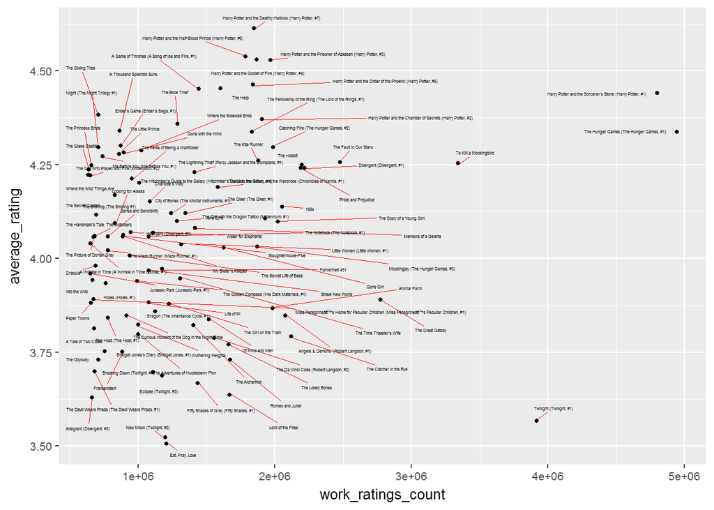

```r
library(ggrepel)
 books %>%
  mutate(image = paste0('<img src="', small_image_url, '"></img>')) %>%
  arrange(-work_ratings_count) %>%
  top_n(100,wt = work_ratings_count) %>%
  ggplot( aes(y=average_rating, x=work_ratings_count, label=title)) + geom_point(stat="identity", position="jitter", alpha=1, size=1) + theme_grey() + theme(text=element_text(family="sans", face="plain", color="#000000", size=10, hjust=0.5, vjust=0.5)) + scale_size(range=c(1, 3)) + xlab("work_ratings_count")+geom_text_repel(
        aes(work_ratings_count, average_rating, label = title),
        box.padding = 0.35, point.padding = 0.15,size=1,
        segment.color = 'red', segment.size = 0.3)  + ylab("average_rating")
```

```r
ggsave("popularityvsratings.png")
books %>%
  mutate(image = paste0('<img src="', small_image_url, '"></img>')) %>%
  arrange(-work_ratings_count) %>%
  top_n(100,wt = work_ratings_count)  %>%
  select("average_rating")%>%
  summary()
```

```
##  average_rating
##  Min.   :3.510
##  1st Qu.:3.868
##  Median :4.060
##  Mean   :4.058
##  3rd Qu.:4.250
##  Max.   :4.610
```

```r
summary(c(3.87,3.73,3.84,3.79,3.64,3.89,3.73,4.25,3.97,3.97))
```

```
##    Min. 1st Qu.  Median    Mean 3rd Qu.    Max.
##   3.640   3.745   3.855   3.868   3.950   4.250
```

```r
summary(books$average_rating)
```

```
##    Min. 1st Qu.  Median    Mean 3rd Qu.    Max.
##   2.470   3.850   4.020   4.002   4.180   4.820
```

So let’s first mean the duplicate ratings.

```r
ratings[, Ndup := .N, .(user_id, item_id)]
cat('Number of duplicate ratings: ', nrow(ratings[Ndup > 1]))
```

```
## Number of duplicate ratings:  0
```

```r
cat('Percent of ratings r duplicate: ', nrow(ratings[Ndup > 1])/nrow(ratings))
```

```
## Percent of ratings r duplicate:  0
```

```r
## corresponding dplyr code
# ratings %>% group_by(user_id, item_id) %>% mutate(n=n())
if(any(ratings$Ndup>1)){
dup.ratings<-ratings[Ndup>1]
dup.ratings[, dupmen := mean(na.rm=T), .(user_id, item_id)]
summary(dup.ratings$rating)
dup.ratings$rating<-dup.ratings$dupmen
summary(dup.ratings$Ndup)
summary(dup.ratings$rating)
##too slow but median would be preffered
#ratings %>%
#  group_by(user_id, item_id) %>%
#  summarize(median_item_user_rating = median(rating))
#  #example in case I forget
#dt <-data.table(date=c('d1','d2','d3','d1','d2','d3'),v1=c('a','c','b','a','b','b'),v2=c(2,2,4,2,4,4))
#dt[, Ndup := .N, .(v1, v2)]
#dups.dt = dt[!duplicated(dt[, .(date, v1, v2)]) ]
dup.ratings <- dup.ratings[!duplicated(dup.ratings[, .(user_id, item_id)]) ]

ratings <- ratings[Ndup == 1]
rbind(ratings,dup.ratings)
rm(dup.ratings)
}
```

And then let’s remove users who rated fewer than 4 items.

```r
ratings[, NU := .N, .(user_id)]
## corresponding dplyr code
# ratings %>% group_by(user_id) %>% mutate(n = n())
cat('Number of users who rated fewer than 4 items: ', uniqueN(ratings[NU <= 3, user_id]))
```

```
## Number of users who rated fewer than 4 items:  0
```

```r
ratings <- ratings[NU > 3]
```

And then let’s remove items rated fewer than 4 times.

```r
ratings[, NI := .N, .(item_id)]
## corresponding dplyr code
# ratings %>% group_by(user_id) %>% mutate(n = n())
cat('Number of items rated fewer than 4 times: ', uniqueN(ratings[NI <= 3, item_id]))
```

```
## Number of items rated fewer than 4 times:  0
```

```r
ratings <- ratings[NI > 3]
```

#### Select a subset of users

To reduce calculation times in EDA, I select only a subset of users. (e.g., 50%)

```r
set.seed(1)
user_fraction <- 0.5
users <- unique(ratings$user_id)
sample_users <- sample(users, round(user_fraction * length(users)))

cat('Number of ratings (before): ', nrow(ratings))
```

```
## Number of ratings (before):  5976479
```

```r
ratings <- ratings[user_id %in% sample_users]
cat('Number of ratings (after): ', nrow(ratings))
```

```
## Number of ratings (after):  2990667
```

### Let’s start the Exploration

#### What is the distribution of ratings?

We see that people tend to give quite positive ratings to items. Most of the ratings are in the 3-5 range, while very few ratings are in the 1-2 range. ~ Notice the distributions of ratings of users with more ratings are much closer to bellcurve then those with few. Users with few ratings tend to remeber thair favorites and rate accordingly. You will probably do that too. See Most Popular Items. This is why ratings should not be normalized over user mean. At least not before normalizing for item mean. Amount users overrate or underrate still depends partly on number of items rated as shown in regressions far bellow. Because I like graphs and thouruoghness this is repeated for items. Where its the opposite; implying popularity and ratings correlate. This is contrary to later correlations probably because here compare each rating rather than each user/item. And I don’t have the skills to take this further.

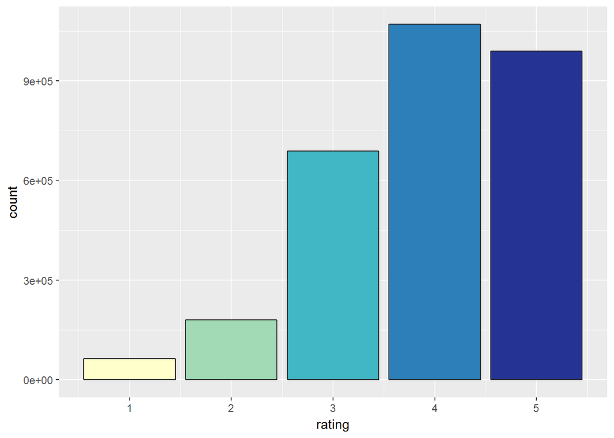

```r
ratings %>%
  ggplot(aes(x = rating, fill = factor(rating))) +
  geom_bar(color = "grey20") + scale_fill_brewer(palette = "YlGnBu") +
  guides(fill = FALSE)
```

```r
summary(ratings$rating)
```

```
##    Min. 1st Qu.  Median    Mean 3rd Qu.    Max.
##   1.000   3.000   4.000   3.917   5.000   5.000
```

```r
ratings %>%
  filter(between(NU,quantile(NU,probs=.9,na.rm=T),max(NU)))%>%
  summary(NU)
```

```
##     user_id         item_id          rating           Ndup
##  Min.   :   75   Min.   :    1   Min.   :1.000   Min.   :1
##  1st Qu.:11073   1st Qu.:  177   1st Qu.:3.000   1st Qu.:1
##  Median :22212   Median :  671   Median :4.000   Median :1
##  Mean   :23797   Mean   : 1625   Mean   :3.832   Mean   :1
##  3rd Qu.:35967   3rd Qu.: 2155   3rd Qu.:5.000   3rd Qu.:1
##  Max.   :53366   Max.   :10000   Max.   :5.000   Max.   :1
##        NU              NI
##  Min.   :152.0   Min.   :   33
##  1st Qu.:156.0   1st Qu.:  648
##  Median :162.0   Median : 1830
##  Mean   :164.5   Mean   : 3502
##  3rd Qu.:170.0   3rd Qu.: 4759
##  Max.   :200.0   Max.   :22806
```

```r
ratings %>%
  filter(between(NU,min(NU),quantile(NU,probs=.1,na.rm=T)))%>%
  summary(NU)
```

```
##     user_id         item_id          rating           Ndup
##  Min.   :   17   Min.   :    1   Min.   :1.000   Min.   :1
##  1st Qu.:18780   1st Qu.:  260   1st Qu.:3.000   1st Qu.:1
##  Median :32414   Median : 1332   Median :4.000   Median :1
##  Mean   :30679   Mean   : 2534   Mean   :4.005   Mean   :1
##  3rd Qu.:43667   3rd Qu.: 4173   3rd Qu.:5.000   3rd Qu.:1
##  Max.   :53407   Max.   :10000   Max.   :5.000   Max.   :1
##        NU              NI
##  Min.   :20.00   Min.   :    8
##  1st Qu.:72.00   1st Qu.:  273
##  Median :80.00   Median :  848
##  Mean   :76.23   Mean   : 2858
##  3rd Qu.:85.00   3rd Qu.: 3353
##  Max.   :88.00   Max.   :22806
```

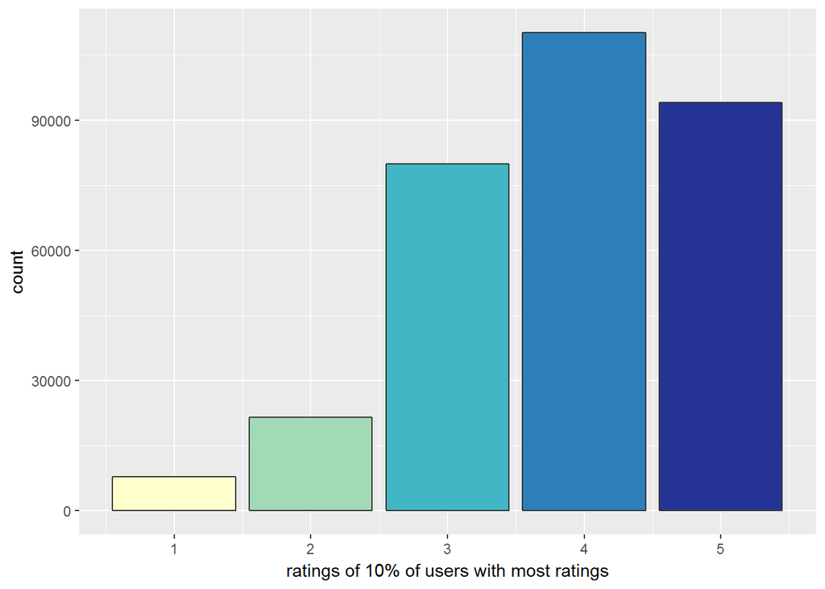

```r
ratings %>%
  filter(between(NU,quantile(NU,probs=.9,na.rm=T),max(NU)))%>%
  ggplot(aes(x = rating, fill = factor(rating))) +
  geom_bar(color = "grey20") + scale_fill_brewer(palette = "YlGnBu") +
  guides(fill = FALSE)+ xlab("ratings of 10% of users with most ratings")
```

```r
quantile(ratings$NU,probs=.1,na.rm=T)
```

```
## 10%
##  88
```

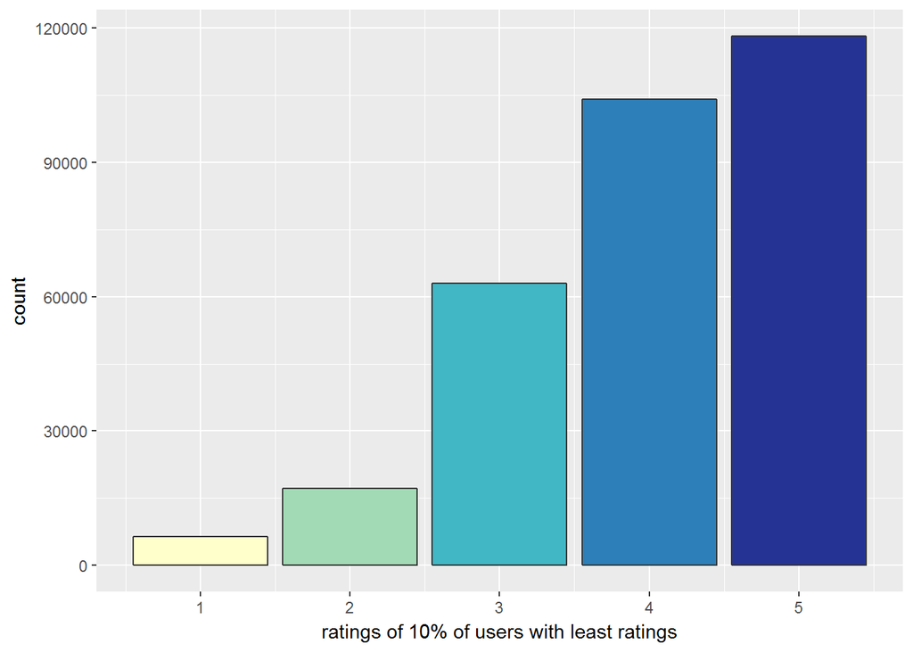

```r
ratings %>%
  filter(between(NU,min(NU),quantile(NU,probs=.1,na.rm=T)))%>%
  ggplot(aes(x = rating, fill = factor(rating))) +
  geom_bar(color = "grey20") + scale_fill_brewer(palette = "YlGnBu") +
  guides(fill = FALSE)+ xlab("ratings of 10% of users with least ratings")
```

```r
ratings %>%
  filter(between(NI,quantile(NI,probs=.9,na.rm=T),max(NI)))%>%
  summary(NI)
```

```
##     user_id         item_id          rating           Ndup
##  Min.   :    1   Min.   : 1.00   Min.   :1.000   Min.   :1
##  1st Qu.:12766   1st Qu.: 9.00   1st Qu.:3.000   1st Qu.:1
##  Median :25830   Median :20.00   Median :4.000   Median :1
##  Mean   :26240   Mean   :21.28   Mean   :4.053   Mean   :1
##  3rd Qu.:39743   3rd Qu.:31.00   3rd Qu.:5.000   3rd Qu.:1
##  Max.   :53424   Max.   :54.00   Max.   :5.000   Max.   :1
##        NU              NI
##  Min.   : 20.0   Min.   : 9960
##  1st Qu.:102.0   1st Qu.:11780
##  Median :116.0   Median :13556
##  Mean   :118.3   Mean   :14227
##  3rd Qu.:134.0   3rd Qu.:15657
##  Max.   :200.0   Max.   :22806
```

```r
ratings %>%
  filter(between(NI,min(NI),quantile(NI,probs=.1,na.rm=T)))%>%
  summary(NI)
```

```
##     user_id         item_id          rating           Ndup
##  Min.   :    1   Min.   : 1129   Min.   :1.000   Min.   :1
##  1st Qu.:13912   1st Qu.: 6393   1st Qu.:3.000   1st Qu.:1
##  Median :27705   Median : 7652   Median :4.000   Median :1
##  Mean   :27282   Mean   : 7467   Mean   :3.888   Mean   :1
##  3rd Qu.:40843   3rd Qu.: 8781   3rd Qu.:5.000   3rd Qu.:1
##  Max.   :53424   Max.   :10000   Max.   :5.000   Max.   :1
##        NU              NI
##  Min.   : 20.0   Min.   :  8.0
##  1st Qu.: 93.0   1st Qu.:128.0
##  Median :108.0   Median :155.0
##  Mean   :109.3   Mean   :153.4
##  3rd Qu.:125.0   3rd Qu.:182.0
##  Max.   :200.0   Max.   :209.0
```

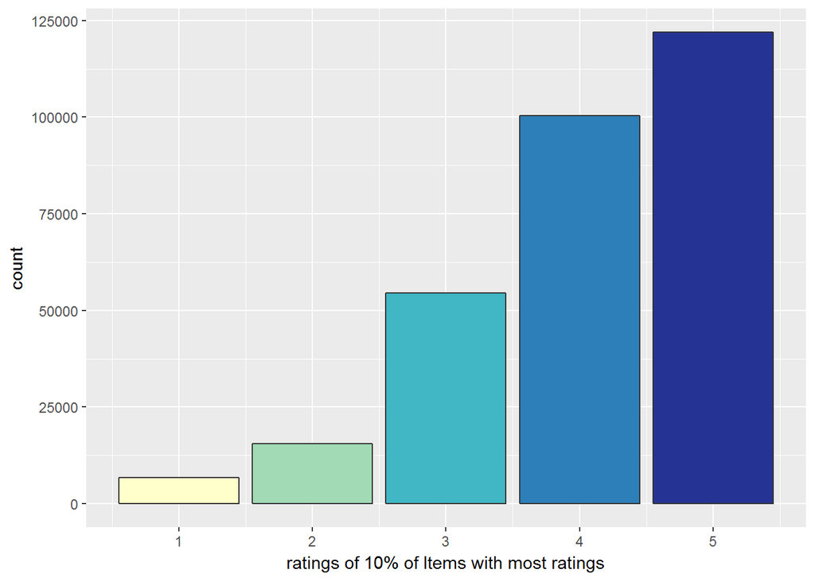

```r
ratings %>%
  filter(between(NI,quantile(NI,probs=.9,na.rm=T),max(NI)))%>%
  ggplot(aes(x = rating, fill = factor(rating))) +
  geom_bar(color = "grey20") + scale_fill_brewer(palette = "YlGnBu") +
  guides(fill = FALSE)+ xlab("ratings of 10% of Items with most ratings")
```

```r
quantile(ratings$NI,probs=.1,na.rm=T)
```

```
## 10%
## 209
```

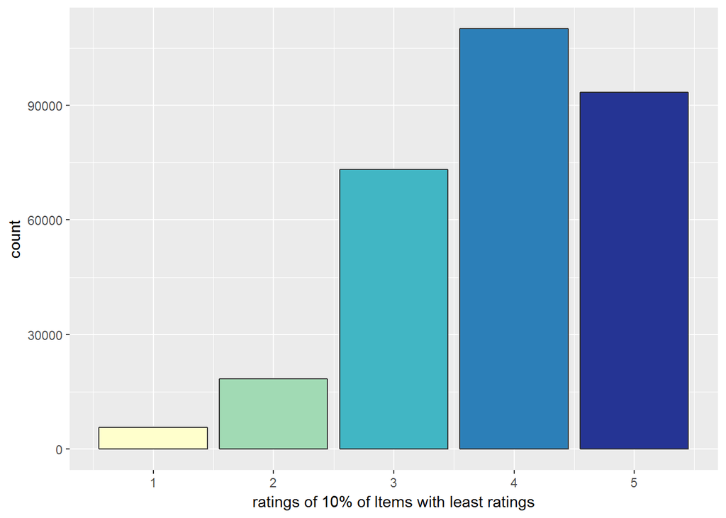

```r
ratings %>%
  filter(between(NI,min(NI),quantile(NI,probs=.1,na.rm=T)))%>%
  ggplot(aes(x = rating, fill = factor(rating))) +
  geom_bar(color = "grey20") + scale_fill_brewer(palette = "YlGnBu") +
  guides(fill = FALSE)+ xlab("ratings of 10% of Items with least ratings")
```

#### Number of ratings per user

As we filtered our ratings all users have at least 3 ratings. However, we can also see that are some users with many ratings. This is interesting, because we can later examine whether frequent raters rate items differently from less frequent raters. We will come back to this later.

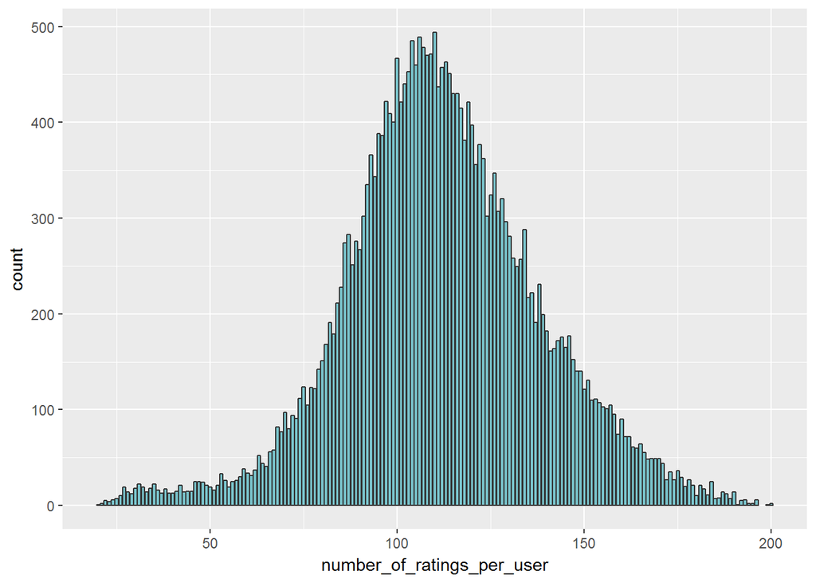

```r
ratings %>%
  group_by(user_id) %>%
  summarize(number_of_ratings_per_user = n()) %>%
  ggplot(aes(number_of_ratings_per_user)) +
  geom_bar(fill = "cadetblue3", color = "grey20") #+ coord_cartesian(c(3, 50))
```

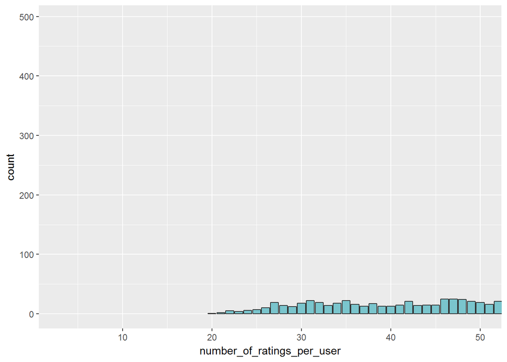

```r
ratings %>%
  group_by(user_id) %>%
  summarize(number_of_ratings_per_user = n()) %>%
  ggplot(aes(number_of_ratings_per_user)) +
  geom_bar(fill = "cadetblue3", color = "grey20") + coord_cartesian(c(3, 50))
```

#### Number of ratings per item As we filtered our ratings all items have at least 3 ratings. However, we can also see that are some items with many ratings. This is interesting, because we can later examine whether frequent raters rate items differently from less frequent raters. We will come back to this later.

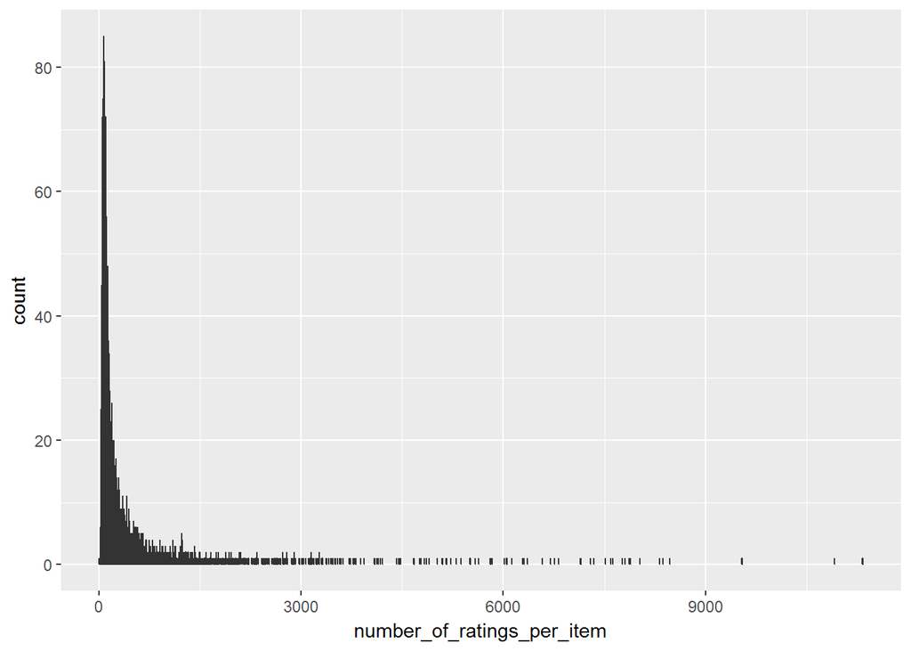

```r
ratings %>%
  group_by(item_id) %>%
  summarize(number_of_ratings_per_item = n()) %>%
  ggplot(aes(number_of_ratings_per_item)) +
  geom_bar(fill = "orange", color = "grey20") #+ coord_cartesian(c(3, 50))
```

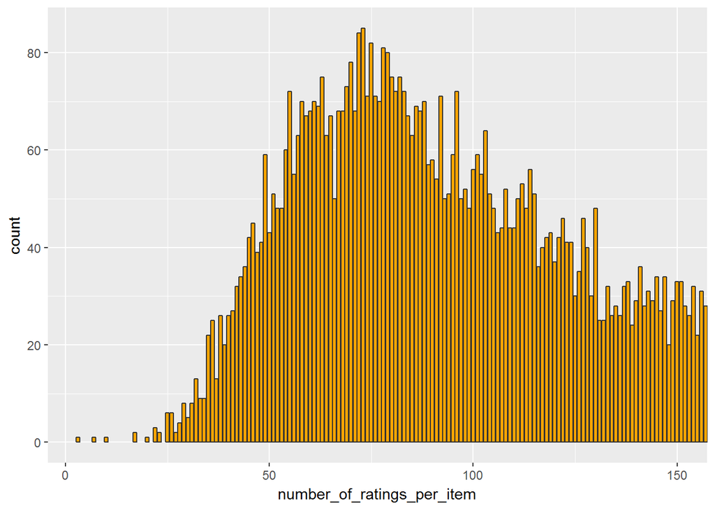

```r
ratings %>%
  group_by(item_id) %>%
  summarize(number_of_ratings_per_item = n()) %>%
  ggplot(aes(number_of_ratings_per_item)) +
  geom_bar(fill = "orange", color = "grey20") + coord_cartesian(c(3, 150))
```

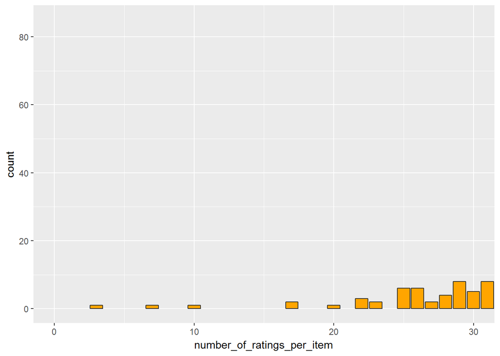

```r
ratings %>%
  group_by(item_id) %>%
  summarize(number_of_ratings_per_item = n()) %>%
  ggplot(aes(number_of_ratings_per_item)) +
  geom_bar(fill = "orange", color = "grey20") + coord_cartesian(c(0, 30))
```

Now that you can see the distribution let’s remove users who rated fewer than your choice of items.

```r
ratings[, NU := .N, .(user_id)]
## corresponding dplyr code
# ratings %>% group_by(user_id) %>% mutate(n = n())
cat('Number of users who rated fewer than N items: ', uniqueN(ratings[NU <= 10, user_id]))
```

```
## Number of users who rated fewer than N items:  0
```

```r
ratings <- ratings[NU > 10]
```

And then let’s remove items rated fewer than your choice of times.

```r
ratings[, NI := .N, .(item_id)]
## corresponding dplyr code
# ratings %>% group_by(user_id) %>% mutate(n = n())
cat('Number of items rated fewer than N times: ', uniqueN(ratings[NI <= 15, item_id]))
```

```
## Number of items rated fewer than N times:  3
```

```r
ratings <- ratings[NI > 15]
```